# Analysis of the Migration Range of the American Redstart (Setophaga ruticilla) from 2004 to 2024

### Introduction

The American Redstart (Setophaga ruticilla) is a colorful warbler that migrates across the Americas each year. Males have a dark black head and chest, with bright orange on the wings, sides, and tail, while females are a lighter grey color with yellow highlights. These warblers prefer nesting in open woodlands across North America [(Cornell Lab of Ornithology)](https://www.allaboutbirds.org/guide/American_Redstart/overview). They spend the winters in Central and South America, and migrate as far as Northern Canada for breeding during the summer. Like many migratory birds, climate change and human developments are impacting the Redstart's migration patterns and survival according to the [Cary Institute of Ecosystem Studies](https://www.caryinstitute.org/news-insights/feature/climate-change-pushing-american-redstarts-breeding-range-southward).

[figure not shown]

### Migration Patterns and Climate Change

American Redstarts are being affected by climate change in some parts of their migration range. According to Bryant Dossman, a conservation and migration ecology scientist, Redstarts are particularly affected by increasingly dry conditions in the tropics of South America and Jamaica where many Redstarts spend the winter [(Heisman, 2024)](https://www.allaboutbirds.org/news/american-redstarts-can-speed-up-their-migration-but-theres-a-cost/). There is strong evidence that increasingly dry conditions in the tropics are linked to climate change and deforestation [(Y. Malhi)](https://royalsocietypublishing.org/rstb/article-abstract/359/1443/331/20382/Tropical-forests-and-the-global-carbon-cycle?redirectedFrom=fulltext). According to Dossman, these conditions are making it harder for the Redstart to find enough food and insects to put on enough weight for the migration journey north. Dossman observes that this causes the Redstart to often leave later in the spring. Dossman used GPS tracking devices on the birds to study their migration speed. He found that bird that left late migrated faster to make up for lost time. However, he notes that migrating faster increases stress and energy expenditure of the birds, making them more likely to die on the journey. Dossman found that birds that left late had a 6% increased risk of death on their migration journey as opposed to birds that left on time [(Heisman, 2024)](https://www.allaboutbirds.org/news/american-redstarts-can-speed-up-their-migration-but-theres-a-cost/). These factors are impacting the Redstarts range. For example, according to the Cary Institute of Ecosystem Studies, the Redstart is migrating farther south into South America during the winters in search of food, and not as far north into Canada during the summers because of the delay migrating north. The overall effect is that the Redstart's range is shifting southwards [(Cary Institute of Ecosystem Studies)](https://www.caryinstitute.org/news-insights/feature/climate-change-pushing-american-redstarts-breeding-range-southward).

### Migration Mapping

Because of the impacts described above, knowing the month-by-month range of the Redstart's migration path can be a useful tool for conservation efforts. In addition to the month-by-month range, assessing the range over years and decades can confirm important information about how climate change is impacting the Redstart's range.

### Migration Data from GBIF

To map the Redstart's annual migration, I will be using occurrence data from the [Global Biodiversity Information Facility (GBIF)](https://www.gbif.org/). Occurrence data is largely collected using [eBird](https://ebird.org/home) and [iNaturalist](https://www.inaturalist.org/), as well as several other reputable citizen science data sources [(GBIF Data Processing)](https://www.gbif.org/data-processing).

### Ecoregion Data

I will be plotting occurrence (sightings of Redstarts) data within ecoregions to visualize the Redstart migration on a map. For the ecoregion data, I will be using data published in 2017 by [RESOLVE](https://www.resolve.ngo/) and [OneEarth](https://www.oneearth.org/announcing-the-release-of-ecoregion-snapshots/).

### Python workflow

Below is the Python workflow I'm using to complete this analysis. In addition to this notebook, I'm using separate Juypter notebooks for each GBIF download.

```python
# Import packages
import os # For file paths, data management, interacting with the operating system
import pathlib # Object oriented file path management
import time # Time how long operations take in Python
import zipfile # Deal with zip files
from getpass import getpass # Security login for downloading GBIF data
from glob import glob # Search for specific file extensions

# Libraries for data analysis
import pandas as pd # Data analysis for tabular data
import geopandas as gpd # Data analysis for geospatial data
import pygbif.occurrences as occ # Get occurrence data
import pygbif.species as species # Get species data
import requests # Download data

# Libraries for Dynamic mapping
import cartopy.crs as ccrs #Coordinate reference systems
import panel as pn #customize the dynamic map
import hvplot.pandas #make the holoview plot with geo-dataframe
import calendar # Change month numbers to month names
```

```python
# Preparing data to make half-decade migration map

# list of years to be used
years = [2004, 2009, 2014, 2019, 2024]

# empty list of gdfs for the years of use
gdfs = []

# looping through the list of years and appending as geojson
for y in years:
    gdf = gpd.read_file(f"redstart_occurrence_{y}.geojson")
    gdf["year"] = y
    gdfs.append(gdf)

combined_gdf = gpd.GeoDataFrame(pd.concat(gdfs, ignore_index=True))
```

```python
# Manually set extent of the map
xmin = -35000000
xmax = -2000000.0
ymax = 11000000.0
ymin = -4000000.0
```

```python
# Instead of a month-by-month slider, we want a year slider

# Using the list of years we created earlier
year_slider = pn.widgets.DiscreteSlider(
    name='Year',
    options={str(y): y for y in years}
)
```

```python
# Combine
combined_gdf = gpd.GeoDataFrame(pd.concat(gdfs, ignore_index=True))

# Ensure CRS is set
if combined_gdf.crs is None:
    combined_gdf.set_crs("EPSG:4326", inplace=True)

# Fix invalid geometries
combined_gdf["geometry"] = combined_gdf.buffer(0)

# Project to Mercator
combined_gdf = combined_gdf.to_crs("EPSG:3395")

# Remove empty geometries
combined_gdf = combined_gdf[~combined_gdf.geometry.is_empty]
```

```python
# Create the interative plot using hvplot

migration_plot_years = (
    combined_gdf
    .hvplot(
        c='norm_occurrences',
        groupby='year',
        geo=True, crs=ccrs.Mercator(),
        tiles='CartoLight',
        xlim=(xmin, xmax),
        ylim=(ymin, ymax),
        frame_height=500,
        widgets={'year': year_slider},
        widget_location='bottom',
        title="American Redstart Range by Year"
    )
)

#Display the plot
migration_plot_years

# Save the plot
migration_plot_years.save("redstart-migration-years.html", embed=True)
```

[output not shown]

### Works Cited

Cornell Lab of Ornithology. American Redstart. https://www.allaboutbirds.org/guide/American_Redstart/overview

Cary Institute of Ecosystem Studies. Climate change is pushing the American redstart’s breeding range southward. https://www.caryinstitute.org/news-insights/feature/climate-change-pushing-american-redstarts-breeding-range-southward

Heisman, Rebecca. American Redstarts Can Speed Up Their Migration, but There’s a Cost. Cornell Lab of Ornithology. 2024. https://www.allaboutbirds.org/news/american-redstarts-can-speed-up-their-migration-but-theres-a-cost/.

Y. Malhi, O. L. Phillips, Wolfgang Cramer, Alberte Bondeau, Sibyll Schaphoff, Wolfgang Lucht, Benjamin Smith, Stephen Sitch; Tropical forests and the global carbon cycle: impacts of atmospheric carbon dioxide, climate change and rate of deforestation. Philos Trans R Soc Lond B Biol Sci 29 March 2004; 359 (1443): 331–343. https://doi.org/10.1098/rstb.2003.1428

# **Trial Code** NDVI Analysis (Codespaces)

```python
# Set up a project and folder for data using earthpy
project = earthpy.Project("Gila River Vegetation", dirname = 'ndvi_project')
```

[output not shown]

```python
# Ecoregions data from GeographyRealm, RESOLVE, and OneEarth:
# GeographyRealm: https://www.geographyrealm.com/terrestrial-ecoregions-gis-data/
# OneEarth: https://www.oneearth.org/announcing-the-release-of-ecoregion-snapshots/
eco_url = (
    "https://storage.googleapis.com/teow2016/Ecoregions2017.zip")

# Set up a path to save the data to your machine
eco_dir = "data/ecoregions"
os.makedirs(eco_dir, exist_ok=True)
# Make ecoregions directory
os.makedirs(eco_dir, exist_ok=True)

# Join ecoregions shapefile path
eco_path = os.path.join(eco_dir, 'ecoregions.shp')

# Only download once
if not os.path.exists(eco_path):
    my_gdf = gpd.read_file(eco_url)
    my_gdf.to_file(eco_path)
```

| ecoregion_id | name | area | geometry |
| --- | --- | --- | --- |
| 1.0 | Adelie Land tundra | 0.038948 | MULTIPOLYGON (((158.7141 -69.60657, 158.71264 ... |
| 2.0 | Admiralty Islands lowland rain forests | 0.170599 | MULTIPOLYGON (((147.28819 -2.57589, 147.2715 -... |
| 3.0 | Aegean and Western Turkey sclerophyllous and m... | 13.844952 | MULTIPOLYGON (((26.88659 35.32161, 26.88297 35... |
| 4.0 | Afghan Mountains semi-desert | 1.355536 | MULTIPOLYGON (((65.48655 34.71401, 65.52872 34... |
| 5.0 | Ahklun and Kilbuck Upland Tundra | 8.196573 | MULTIPOLYGON (((-160.26404 58.64097, -160.2673... |

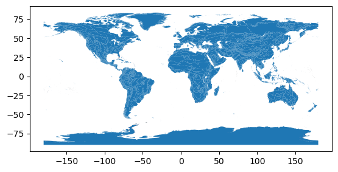

```python
# Opening the download and renaming some of the column names
eco_gdf = (
    gpd.read_file(eco_path)
    [['OBJECTID','ECO_NAME','SHAPE_AREA','geometry']]
    .rename(columns={
        'OBJECTID': 'ecoregion_id',
        'ECO_NAME': 'name',
        'SHAPE_AREA': 'area'
    })
    .set_index('ecoregion_id')
)

# Plot the ecoregions quickly to check download
eco_gdf.plot()
eco_gdf.head()
```

```python
selected = eco_gdf[(eco_gdf["name"] == "Northwest Territories taiga") |
                   (eco_gdf["name"] == "Muskwa-Slave Lake taiga")]
```

```python
selected_merc = selected.to_crs("EPSG:3395")  # or ccrs.Mercator()
selected_merc.hvplot(geo=True, crs="EPSG:3395")
```

[output not shown]